# Sitmo

## Drawing an Integer

```r
library(Rcpp)
sourceCpp("drawNInt.cpp")
```

The key part of the script is that we pass in a seed and we use it to set up the engine. This engine, as we will see, will work well with the boost distributions. For now we can simply feed the seed into the engine by casting it into a `uint32_t`

```cpp
// Firstly we set up the engine. When this is called, it will generate a random number
// between 0 and sitmo::prng::max(). We need to feed into the engine a seed, but we need to cast it
uint32_t casted_seed = static_cast<uint32_t>(seed);
sitmo::prng engine(casted_seed);
```

and then we can call the engine to draw a random integer, in a similar way as to the `IntroCpp` portfolio.

```cpp
for (unsigned int i=0; i < n; i++){
  draws(i) = engine();
}
```

Running the function, we can see that it does indeed the job.

```r
drawNInt(10, 1)
```

```
##  [1] 1931275270  145858287 3604276868 3225543903  409150833  835237719
##  [7]  105088306 2341906412 1694854706 4171159864
```

## Bootstrap Filter

We can do a more advanced example by trying to parallelize a BootstrapFilter. The sequential bootstrap filter is given in `BootstrapFilter.cpp`. This is run on the usual example by Gordon (1993). We can see that it does a good job at inferring the hidden state.

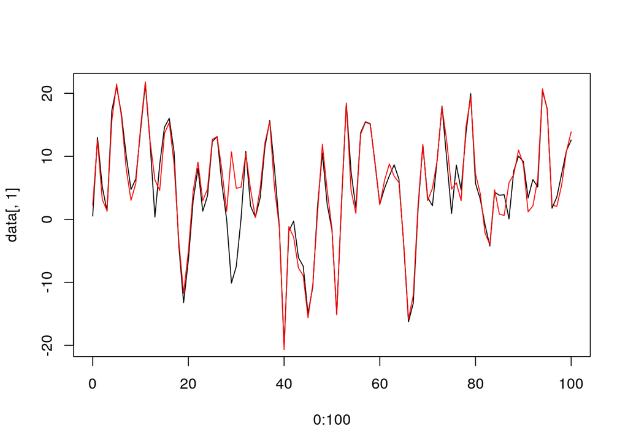

```r
sourceCpp("BootstrapFilter.cpp")
data = generate_data(t_max = 100, transition_scale = sqrt(10), emission_scale = 1.0, prior_scale = sqrt(10))
out = particle_filter(t_max=100, n_particles = 200, y=data[, 2], prior_mean = 0.0,
                      prior_scale = sqrt(10), transition_scale = sqrt(10), likelihood_scale = 1.0)
plot(0:100, data[, 1], type='l')
lines(0:100, apply(out, 1, mean), type='l', col='red')
```

We can also run the parallel version and see similar results.

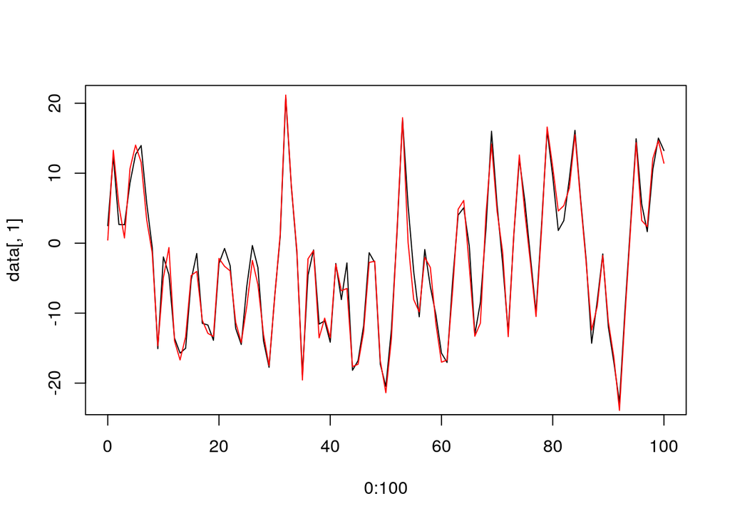

```r
sourceCpp("BootstrapFilterParallel.cpp")
data = generate_data(t_max = 100, transition_scale = sqrt(10), emission_scale = 1.0, prior_scale = sqrt(10))
out = particle_filter_par(t_max=100, n_particles = 200, y=data[, 2], prior_mean = 0.0,
                      prior_scale = sqrt(10), transition_scale = sqrt(10), likelihood_scale = 1.0, ncores=5)
plot(0:100, data[, 1], type='l')
lines(0:100, apply(out, 1, mean), type='l', col='red')
```

Let’s compare the two versions. We can see that the parallel version is almost twice as fast as the sequential version!

```r
data = generate_data(t_max = 100, transition_scale = sqrt(10), emission_scale = 1.0, prior_scale = sqrt(10))
np = 1500 # number of particles
library(microbenchmark)
microbenchmark(seq=particle_filter(t_max=100, n_particles = np, y=data[, 2], prior_mean = 0.0,
                      prior_scale = sqrt(10), transition_scale = sqrt(10), likelihood_scale = 1.0),
               par=particle_filter_par(t_max=100, n_particles = np, y=data[, 2], prior_mean = 0.0,
                      prior_scale = sqrt(10), transition_scale = sqrt(10), likelihood_scale = 1.0, ncores=4), unit="relative")
```

```
## Unit: relative
##  expr      min      lq     mean   median       uq      max neval
##   seq 1.828298 1.82411 1.836613 1.795492 1.820468 1.906248   100
##   par 1.000000 1.00000 1.000000 1.000000 1.000000 1.000000   100
```

```cpp
RcppParallel::RMatrix<double> Pparticles(particles);
```

Next, since we have already defined the output matrix `particles` we can set the RNG scope, this is to avoid a frequent bug in Rcpp.

```cpp
RNGScope scope;
```

Now what we want to do is to have different seeds

```cpp
NumericVector seeds(ncores);
for (unsigned int ii=0; ii < ncores; ii++){
  seeds[ii] = random_int(100*ii + 1, 100*ii + 100);
}
```

Therefore we sample the seeds uniformly from different intervals, to avoid the possibility in which different threads have the same seed. Inside the main for loop (over time) we also grab the corresponding seed from `seeds` using `omp_get_thread_num()` and we use it to seed an engine.

```cpp
uint32_t coreSeed = static_cast<uint32_t>(seeds[omp_get_thread_num()]);   // grab the corresponding seed and cast it
sitmo::prng_engine coreEngine = sitmo::prng_engine(coreSeed);    // grab the engine
```

Then we parallelize all the bits that are parallelizable (except the resampling step) using the following structure:

```cpp
#pragma omp parallel num_threads(ncores)
{
  #pragma omp for schedule(static)
  for (unsigned int particle_index=0; particle_index < n_particles; particle_index ++){
    // CODE
  }
}
```

The trickiest bit is when we need to sample from the transition distribution.

```cpp
#pragma omp parallel num_threads(ncores)
{
  #pragma omp for schedule(static)
  for (unsigned int particle_index=0; particle_index < n_particles; particle_index ++){
    // instantiate the distribution
    boost::random::normal_distribution<float> trans(meanfunc(Pparticles(i-1, particle_index), i), transition_scale);
    //particles(i, particle_index) = transition(particles(i-1, particle_index), i, transition_scale); //trans(coreEngine);
    particles(i, particle_index) = trans(coreEngine);
  }
}
```

We can see that we instantiate a `boost` normal distribution and we use `Pparticles` rather than `particles` because it is thread-safe. Then we feed the corresponding engine to the distribution, to sample from the transition.